# Clustering Tendency

First, we use the Hopkins statistic (Lawson and Jurs 1990) denoted as H to assess the clustering tendency. If there is no clustering tendency, H would be about 0.5. A value for H higher than 0.75 indicates a clustering tendency at the 90% confidence level(Han, Kamber, and Pei 2012).

```
## [1] 0.937
```

# The Elbow Method

For the elbow method, in which the sum of squares at each number of clusters is calculated and graphed, we can look for a change of slope from steep to shallow to determine the optimal number of clusters.

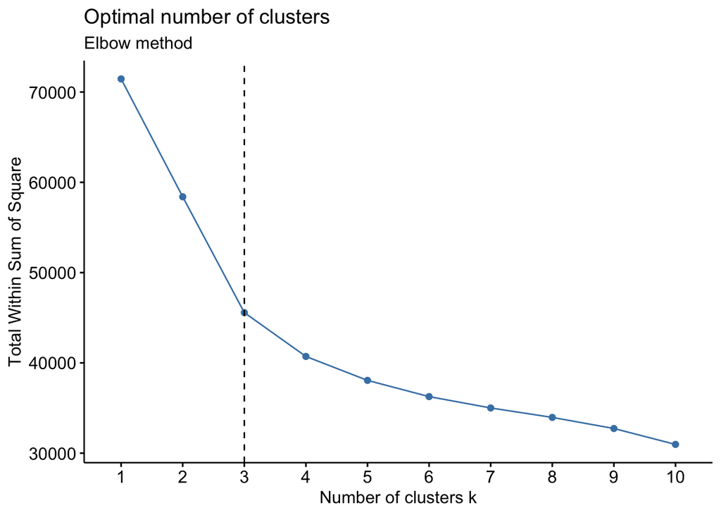

The optimal cluster number given by the elbow method is 3.

# The Silhouette Method

The Silhouette method computes the average silhouette of observations for different numbers. The optimal number of clusters is the one that maximizes the average silhouette over a range of possible values.

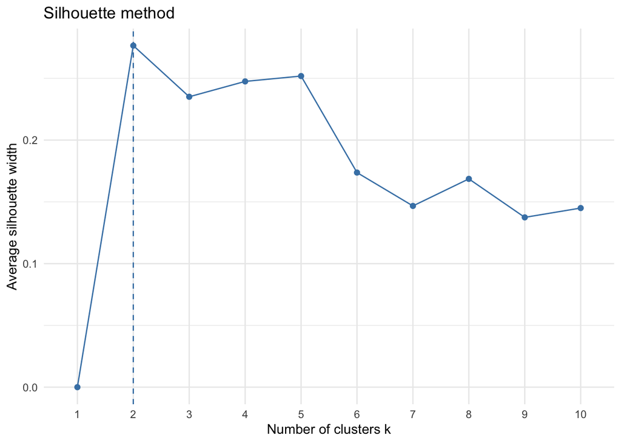

The optimal cluster number given by the Silhouette method is 2, which is different from the value that elbow method suggests.

## 2.3 NbClust

The NbClust package provides variou indices for determining the relevant number of clusters and proposes to users the best clustering scheme from the different results by using the majority rule.

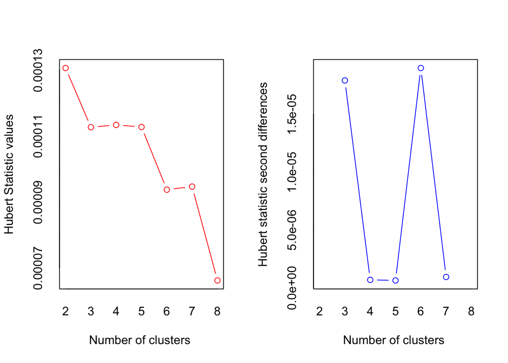

```
## *** : The Hubert index is a graphical method of determining the number of clusters.
##                 In the plot of Hubert index, we seek a significant knee that corresponds to a
##                 significant increase of the value of the measure i.e the significant peak in Hubert
##                 index second differences plot.
##
```

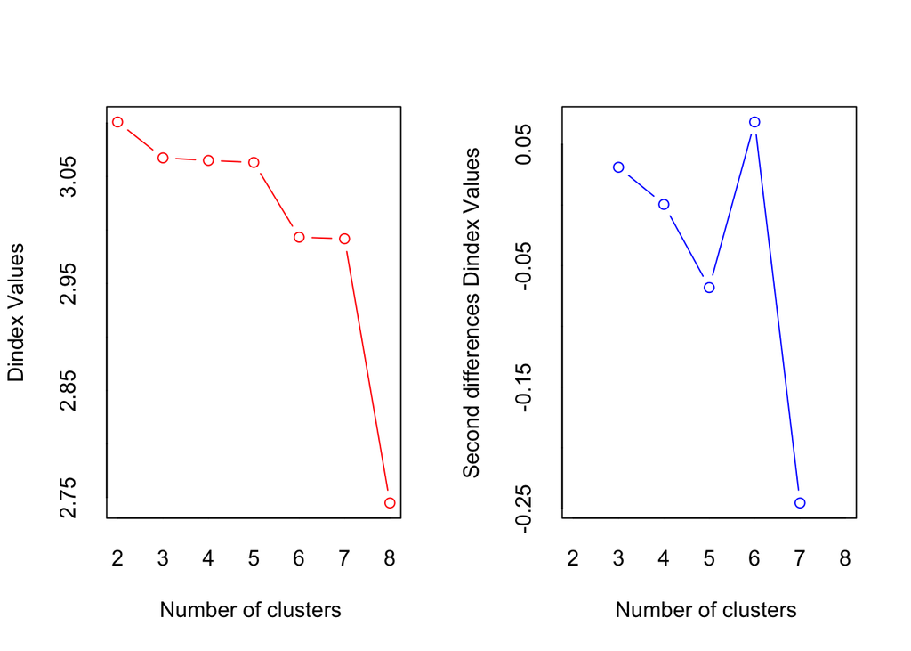

```
## *** : The D index is a graphical method of determining the number of clusters.
##                 In the plot of D index, we seek a significant knee (the significant peak in Dindex
##                 second differences plot) that corresponds to a significant increase of the value of
##                 the measure.
##
## * Among all indices:
## * 13 proposed 2 as the best number of clusters
## * 1 proposed 3 as the best number of clusters
## * 1 proposed 5 as the best number of clusters
## * 3 proposed 6 as the best number of clusters
## * 1 proposed 7 as the best number of clusters
## * 5 proposed 8 as the best number of clusters
##
##                    ***** Conclusion *****
##
## * According to the majority rule, the best number of clusters is  2
##
##
```

```
## Among all indices:
## ===================
## * 2 proposed  0 as the best number of clusters
## * 13 proposed  2 as the best number of clusters
## * 1 proposed  3 as the best number of clusters
## * 1 proposed  5 as the best number of clusters
## * 3 proposed  6 as the best number of clusters
## * 1 proposed  7 as the best number of clusters
## * 5 proposed  8 as the best number of clusters
##
## Conclusion
## =========================
## * According to the majority rule, the best number of clusters is  2 .
```

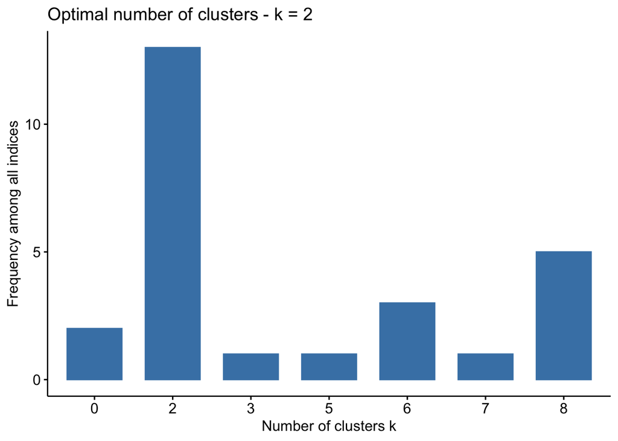

Based on the analysis above, since k = 2 has the most votes, we will choose k = 2 to be the optimal cluster number.